# Logistic Regression

# Preamble

```r
library(ggplot2)
library(dplyr)
```

Up until this point with regression, we have been interested in estimating the value of a numeric outcome (dependent variable) using a linear function of covariates,

$$\hat{y} = X \hat{\beta}.$$

A consequence of our outcome being both continuous and numeric is that it can take on an indefinite number of values. In the plot below, a valid value of $\hat{y}$ could be any number on the blue line.

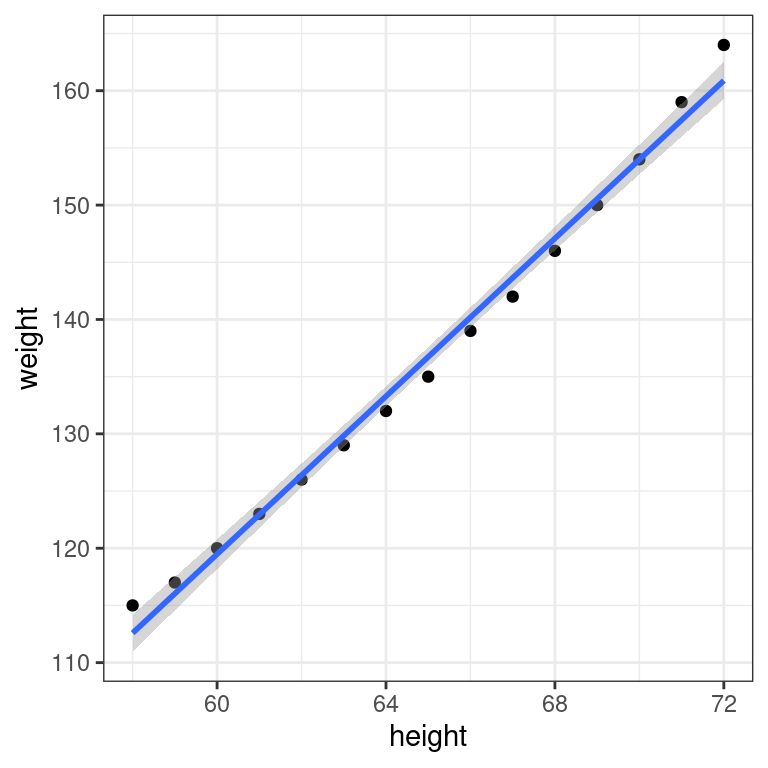

That is, given any value of height in the interval shown, we could estimate a unique value for weight.

This is in sharp contrast to a situation in which our outcome is *categorical*, characterized by membership in one group or another; examples of this include the outcome of an experiment being success or failure, the presence of absence of side effects in a clinical trial, or whether or not somebody decides to get a flu shot. Unlike a continuous outcome, categorical outcomes are often restricted to two values: yes or no.

## Notation and Concepts

A term we will use frequently in our study of logistic regression will be that of *odds*. A term that you are likely familiar with to some degree, *odds* are typically reported as a ratio giving the number of successes to the number of failures. For example, if I were to tell you that the odds of winning something were “3 to 1” or 3:1, this would mean that you should anticipate three successes for every one failure. This is distinct from expressing it as a probability, in which case we would present a ratio of an event to the total. Here, “3 to 1” odds indicates 4 total events (three success, one failure), so our *probability* of success is 3/4 (three successes out of four trials) while the *probability* of failure is 1/4. From this, we find that our odds ratio is in fact a ratio of probabilities:

$$odds = 3:1 \equiv \frac{3}{1} = \frac{3/4}{1/4} = \frac{\pi}{1-\pi}$$

We can also see from this, then, that the probability of success, $\pi$, is $\pi = 3/4 = 75\%$ while the probability of failure is $1 - \pi = 25\%$.

**Question 1:** Answer the following questions about odds:

1. Suppose that I tell you your odds of success in playing a game are 6 to 4. How would you interpret this?
2. If the odds of success are 6 to 4, what is the probability of success?
3. Now suppose that I *double* the odds to be 12 to 4. How has this changed the probability of success?
4. What if instead I *halved* the odds?
5. Are there any positive numbers you could multiply the odds ratio by so that the probability of success is greater than 1? How about less than 0?

Rather than determining success or failure directly, the goal of logistic regression is to estimate the probability of success based on the values of the independent variables. For reasons just beyond the scope of this lab, we will simply note that the form of logistic regression seeks to estimate parameter values $\beta$ based on the *log odds* of the probability:

$$\log \left( \frac{\pi}{1-\pi} \right) = \beta_0 + X_1 \beta_1 + X_2
\beta_2 + \dots + X_p\beta_p$$

Exponentiating both sides brings us back to the odds ratio from before:

$$\begin{align}
\frac{\pi}{1-\pi} &= \exp \left( \beta_0 + X_1 \beta_1 + X_2 \beta_2
+ \dots + X_p\beta_p \right) \\
&= \exp \left(\beta_0 \right) \times \exp \left(X_1 \beta_1 \right)
\times \dots \times \exp \left(X_p \beta_p \right)
\end{align}$$

Based on these expression, we have the following interpretation: for any fitted value $\hat{\beta_j}$, a unit increase in $X_j$ results in a multiplication of the odds by a factor $\exp (\hat{\beta_j})$. Note further the parallel between the previous labs: when $\hat{\beta} = 0$, we assumed that $X$ was not linearly related to $y$. Here, when $\hat{\beta} = 0$, $\exp(X \hat{\beta}) = \exp(0) = 1$, meaning that changes in $X$ result in a multiplicative change in the odds of 1 (i.e., no change). As a corollary to this, negative values of $\beta$ are associated with a decrease in the odds (multiplied by a number less than 1), while positive values of $\beta$ are associated in an increase in the odds.

Another, equivalent way to describe $\exp(\hat{\beta})$ is as an *odds ratio*. The justification for this is provided briefly in the following section.

### Some Extra Algebra

The algebra in this section is not important in and of itself. Rather, for completeness we will demonstrate why $\exp(\hat{\beta})$ is called an odds ratio and then provide a formula for solving directly for an estimated probability, given covariates.

#### Odds Ratio

Suppose that we are interested in considering the impact of $\beta_1$, the variable associated with the covariate $X_1$. From above, we know that

$$\frac{\pi}{1-\pi} = \exp \left(\beta_0 \right) \times \exp \left(X_1
\beta_1 \right)$$

Let $\pi^*$ then denote the odds of a person with all of the same values, except instead of $X_1$ they have $X_1 + 1$, i.e., the only difference is a unit increase in $X_1$. The odds would be

$$\frac{\pi^*}{1-\pi^*} = \exp \left(\beta_0 \right) \times \exp
\left((X_1+1) \beta_1 \right)$$

Separating out this last exponential term, we find

$$\begin{align}
\frac{\pi^*}{1-\pi^*} &= \exp \left(\beta_0 \right) \times \exp
\left((X_1+1) \beta_1 \right) \\
&= \exp \left(\beta_0 \right) \times \exp \left(X_1\beta_1 +
\beta_1 \right) \\
&= \left( \exp \left(\beta_0 \right) \times \exp
\left(X_1\beta_1\right) \right) \times \exp \left(\beta_1 \right) \\
&= \left( \frac{\pi}{1 - \pi} \right)\times \exp \left(\beta_1
\right)
\end{align}$$

Multiplying each side by the inverse of $\pi / (1 - \pi)$ we finally get

$$\exp(\beta_1) = \frac{\frac{\pi^*}{1-\pi^*}}{\frac{\pi}{1-\pi}}$$

which is the ratio of two odds of an observation with covariates $X_1$ and $X_1 + 1$. Just as before, when $\exp(\beta_1) > 1$, the odds increase, whereas $\exp(\beta_1) < 1$ represents a decrease.

#### Defining Probability with Covariates

We can determine the probability of success based on independent variables and fitted coefficients (solved using algebra)

$$\hat{\pi_i} = \frac{\exp (X_i\hat{\beta})}{1 + \exp (X_i\hat{\beta})}$$

Though rarely will we need to do this directly.

## Example

Let’s bring everything we have discussed to this point into a worked example. For this, we will be using the `Donner` dataset.

We start by loading the data and examining the variables present.

```r
# Load data (borrowed from the alr4 package)
Donner <- read.csv("https://collinn.github.io/data/donner.csv")

head(Donner)
```

```
##   age        y    sex family.name status
## 1  13 survived   Male       Breen Family
## 2   1 survived Female       Breen Family
## 3   5 survived   Male       Breen Family
## 4  14 survived   Male       Breen Family
## 5  40 survived Female       Breen Family
## 6  51 survived   Male       Breen Family
```

Here, we see their age in 1846, their sex, family name, whether or not they survived, and a status variable indicating whether or not they were a part of a family, were single, or were hired as part of the expedition. Although it is not strictly required for logistic regression in R, we will create a new variable “death” indicating with a 0 or 1 if that particular member was deceased*. Then, we will construct our logistic regression model using sex and age as our independent variables.

*Note: You can use any factor or even a character vector as your outcome for logistic regression in R. The problem is then figuring out which value the model treated as “success”. By explicitly labeling them 0/1, we exercise more control.

To perform logistic regression, we use the function `glm()` (general linear model) with the argument `family = "binomial"` to indicate a binomial outcome.

```r
## Recategorize outcome as 0/1 and remove NA values
dat <- mutate(Donner,
              death = ifelse(y == "died", 1, 0)) %>%
  na.omit()

fit_log <- glm(death ~ sex + age, data = dat, family = "binomial")

summary(fit_log)
```

```
##
## Call:
## glm(formula = death ~ sex + age, family = "binomial", data = dat)
##
## Coefficients:
##             Estimate Std. Error z value Pr(>|z|)
## (Intercept)  -1.6218     0.5028   -3.23   0.0013 **
## sexMale       1.0680     0.4823    2.21   0.0268 *
## age           0.0356     0.0152    2.34   0.0195 *
## ---
## Signif. codes:  0 '***' 0.001 '**' 0.01 '*' 0.05 '.' 0.1 ' ' 1
##
## (Dispersion parameter for binomial family taken to be 1)
##
##     Null deviance: 120.86  on 87  degrees of freedom
## Residual deviance: 108.87  on 85  degrees of freedom
## AIC: 114.9
##
## Number of Fisher Scoring iterations: 4
```

Just as before, we can use a `summary()` function to display the results (similarly, we can still use nearly all of the functions from the previous lab, `coef()`, `residuals()`, `fitted()`, `anova()`, etc.,). Looking at these coefficients and recalling our method of interpretation from the previous section, we have:

| Variable | $\hat{\beta}$ | $\exp(\hat{\beta})$ | Interpretation |
| --- | --- | --- | --- |
| Intercept | -1.6218 | 0.19754 | None ($age = 0$ is not in our dataset) |
| sex (Male) | 1.06798 | 2.90949 | Being male had 2.9 times the odds of death compared to female |
| Age | 0.03561 | 1.03625 | Odds of death increased by 1.03 for each additional year |

Also like the numeric linear model, we can use the `predict()` function to get fitted values from new data points. In this case, we need to be sure to pass `type = "response"` to be sure that we are getting results in terms of probabilities rather than log odds.

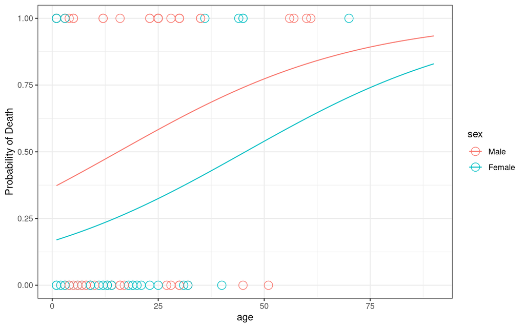

```r
## Create new data.frame with independent variables
newdf <- expand.grid(sex = c("Male", "Female"),
                     age = seq(min(dat$age), 90)) # Extended range for plot aesthetic

yhat <- predict(fit_log, newdf, type = "response")

## Add prediction values to "new" data
newdf$yhat <- yhat

## Plot original values along with prediction
ggplot(newdf, aes(age, yhat, color = sex)) + geom_line() +
  geom_point(data = dat, mapping = aes(age, death, color = sex), shape = 1, size = 4) +
  ylab("Probability of Death")
```

Looking at this plot, we see represented as circles the observed values of our dataset, marked as either a 0 or 1 according to whether or not the individual had died, while the solid lines indicate the probability of death as a continuous function of age.

**Question 2:** Refit a regression model for the Donner dataset, this time using `lm()` to construct a linear model. Additionally, include the covariate “status” from the data, a categorical variable indicating if the member was a part of a family, was a single traveler, or was hired as a guide by the group.

Examining the coefficients of this model, assume that we have a single male who is 35 years old.

1. What is his probability of death?
2. Is this a valid answer?
3. Could this happen using logistic regression? Why or why not?

For the remainder of this lab, we will continue our process of building logistic regression models, interpreting results, and investigating alternate metrics for determining the validity of our models.

# Lab

## Model Building and Interpretation

**Question 3:** The code below loads game data from the Golden State Warriors’ 2016-2016 season. Read in the data below and consider `win_binary` to be our outcome of interest.

```r
gsw <- read.csv("https://remiller1450.github.io/data/GSWarriors.csv")
gsw$win_binary <- ifelse(gsw$Win == "W", 1, 0)
```

**Part A:** Fit a logistic regression model using the formula `win_binary ~ FG3A`, noting that “FG3A” is the number of three-point shots *attempted* in a game. Find the coefficients for this model, exponentiate them, and the interpret the variable associated with FG3A.

**Part B:** Now fit a logistic model using the formula `win_binary ~ FG3A + FG3` where FG3 represents the number of three point shots *made*. Again, find and exponentiate the coefficients and then interpret. Why is the exponentiated coefficient for FG3A less than 1? *Hint:* Recall from previous labs that the coefficient, when interpreted in isolation, assumes that *all other variables are held constant*.

## Methods of Assessment

When our outcome was a numeric variable, calculating the error in our model was simple enough: we could take the observed value $y$, subtract the predicted value $\hat{y}$, and the resulting magnitude of difference gave us the magnitude of the error. In the categorical case, our situation is different: each outcome is marked as being *either* a 0 or a 1, but not both. Further, our model doesn’t directly classify the predicted outcome but rather, gives us an estimated probability of membership in either group.

### Accuracy

For example, consider consider these three people from the Donner party dataset

```r
(newdat <- dat[c(12, 37, 45), ])
```

```
##    age        y    sex family.name status death
## 12  45     died Female    J_Donner Family     1
## 37  57     died   Male      Graves Family     1
## 45  27 survived   Male       Hired  Hired     0
```

We have a woman aged 45 and a male aged 57 who both died, as well as a male aged 27 who survived. Using the `predict()` function, we can find the estimated probabilities of death for each of them.

```r
# Using the Donner Party data to fit the model
fit <- glm(death ~ sex + age, data = dat, family = "binomial")

# Probability of death for each
newdat$prob_death <- predict(fit, newdat, type = "response")
newdat
```

```
##    age        y    sex family.name status death prob_death
## 12  45     died Female    J_Donner Family     1    0.49511
## 37  57     died   Male      Graves Family     1    0.81392
## 45  27 survived   Male       Hired  Hired     0    0.60049
```

That is, the 45 year old woman had a probability of death of 49%, the 57 year old male 81%, and the 27 year old male a 60% of death. Using these probabilities, we need to predict the classification for each of these observations. The most obvious solution is to use a cutoff of 50%: those with a probability greater than 50% we will classify as death, while those with less will be classified as survived. Our *accuracy*, then, is defined as the total correct divided by the total number of observations

$$\text{Accuracy} = \frac1n \sum (y_i = \hat{y}_i)$$

```r
# Classify greater than 0.5 as having died
newdat <- newdat %>%
  mutate(classify_dead = as.numeric(prob_death >= 0.5))

## Our accuracy for this subset
sum(newdat$death == newdat$classify_dead) / nrow(newdat)
```

```
## [1] 0.33333
```

Of the three values we predicted, only 1 was correct resulting in an accuracy of 33%.

To get the accuracy for the whole dataset, we can do the same thing (this time using the `fitted()` function to get fit values (probabilities) from our model)

```r
## Round the probabilities to 1 or 0 first
yhat <- ifelse(fitted(fit) > 0.5, 1, 0)

## Compute the proportion that are correct
# sum(dat$death == yhat) / nrow(dat)

## This does the same thing
mean(dat$death == yhat)
```

```
## [1] 0.67045
```

We see that our overall accuracy is around 67%

Accuracy is often presented alongside a *confusion matrix*, a two-way table of the model’s predicted categories along with their true categories.

```r
## Change 0/1 to survived/died to
yhat <- ifelse(yhat == 0, "survived", "died")

## Make table with dat$y which also contains survived/died
table(dat$y, yhat)
```

```
##           yhat
##            died survived
##   died       21       18
##   survived   11       38
```

Here, the rows represent the true values, while the columns are what was predicted. Taking marginal sums of this table gives us totals. For example, the row for “died” indicates that within the Donner party dataset, 21 + 18 = 39 people actually died. Of these, 21 were correctly predicted to have died while 18 were incorrectly predicted to have survived. Likewise, we see that 11 + 38 = 49 people survived, of these 11 we predicted had died while 38 we correctly predicted had lived.

The following is also noteworthy: of the 39 people who died, we correctly predicted 21/39 = 54% of them. Of the people who survived, we correctly predicted 38/49 = 78%. Even though our overall model had an accuracy of 67%, we see that our accuracy within each of the outcomes is considerably different.

It’s of critical importance to note here that whether or not we predicted an individual would live or die was based entirely on our classification method, the threshold that we set classification. That is, we said that we would classify those with probabilities greater than 0.5 of death as being dead. Changing this cutoff value would result in a new confusion matrix.

**Question 4:** Using the same logistic regression model as above (`y ~ sex + age`), change the threshold of probabilities for survival outcomes to be $0.6$ instead of $0.5$. How does this change the accuracy for our model? What about the accuracy for each of the survival groups? (Hint: Build a confusion matrix)

Repeat the experiment again, this time changing the threshold to $0.4$: what is the accuracy of this model and for each of the survival groups?

Based on this, what considerations would you make if correctly predicting who died was more important to you than overall accuracy?

### Sensitivity and Specificity

One of the things we should have seen in the previous section is accuracy, as a single metric, fails to illustrate crucial aspects of our model. This results from the fact that there are multiple ways to be right as well as multiple ways to be wrong. We differentiate these possibilities with the following terms (using success = 1 and failure = 0):

1. A *True Positive (TP)* is an instance in which we predict success (or death) and it is correct
2. A *False Negative (FN)* is an instance in which we predict failure, when in actuality it is a success
3. A *False Positive (FP)* is when we predict success but in reality is a failure
4. A *True Negative (TN)* is when we correctly predict failure.

These are further summarized in the following table:

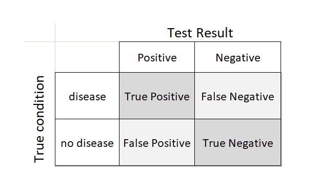

From these quantities, we derive two important metrics:

1. **Sensitivity** is the *true positive rate*:

$$\text{Sensitivity} = \frac{\# \text{True Positives}}{\# \text{True
Positives} + \# \text{False Negatives}}$$

2. **Specificity** is the *true negative rate*:

$$\text{Specificity} = \frac{\# \text{True Negatives}}{\# \text{True
Negatives} + \# \text{False Positives}}$$

In fact, these are values that we have already seen when we previously calculated the accuracy in our model of classifying those who died along with the accuracy with those who survived. As we also saw in Question 4, there is a state of tension between these two: taking efforts to improve sensitivity acts to the detriment of specificity and vice versa.

**Question 5:** To consider an interesting and extreme example of this, suppose there is some rare disease the infects 1 in 10,000 people that can be treated with simple antibiotics if it is detected early, but otherwise results in a gruesome and horrifying death. A group of doctors are considering using one of two alternatives, Test A and Test B, to identify individuals at risk.

Test A, no matter what, will return that the test is negative, even if the person has the disease. It would have a confusion matrix that looks like this:

|  | Tested Positive | Tested Negative |
| --- | --- | --- |
| Has Disease | 0 | 1 |
| Does not have disease | 0 | 9999 |

Test B, on the other hand, will *always* detect the disease, if it is present, but will give a false positive if the patient does not have the disease about 3% of the time. The confusion matrix for Test B would look like this:

|  | Tested Positive | Tested Negative |
| --- | --- | --- |
| Has Disease | 1 | 0 |
| Does not have disease | 300 | 9699 |

Based on these tables, researchers determine that Test A has an accuracy of 99.99% while Test B only has an accuracy of 97%. As such, they decide to go with Test A.

Why is this incorrect? What metrics should they have considered instead?

### ROC Curves

There are two things up to this point that we should feel confident asserting:

1. Accuracy alone is a poor measure of model quality, with sensitivity and specificity providing more relevant information
2. A model does not have a *single* value for sensitivity or specificity: as we saw in question 4, changing the threshold probability for classification

We have already seen above that sensitivity, being the number of *true positives* divided by the total number of actual positives, gives us our *true positive rate*. Our *false positive rate* can be found as being $1 - \text{Specificity}$:

$$\begin{align}
1 - \text{Specificity} &= 1 - \frac{\# \text{True Negatives
(TN)}}{\# \text{True Negatives (TN)} + \# \text{False Positives (FP)}}
\\ \\
&= \frac{ \text{TN} + \text{FP}}{ \text{TN} + \text{FP}} - \frac{
\text{TN}}{ \text{TN} + \text{FP}} \\ \\
&= \frac{ \text{FP}}{ \text{TN} + \text{FP}}
\end{align}$$

Using the false positive rate, or $1 - \text{Specificity}$, is more natural than using specificity alone in that it makes the tension between these two metrics a bit more intuitive: if we lower our threshold for what we consider a success, I should anticipate that I will be more likely to correctly identify true successes (increasing my *true positive rate*), but I should also anticipate that I will be more likely to incorrectly identify those that were actually failures (increasing my *false positive rate*).

Going back to our Donner party data, let’s create a function that takes as an argument a particular threshold and returns both the true positive and the false positive rates:

```r
metrics <- function(thresh = 0.5) {
  yhat <- ifelse(fitted(fit) > thresh, 1, 0)
  yhat <- ifelse(yhat == 0, "survived", "died")
  # Create factor so that table won't drop empty levels
  yhat <- factor(yhat, levels = c("died", "survived"))
  tt <- table(dat$y, yhat)
  res <- c("Sensitivity" = tt[1,1] / sum(tt[1, ]),
           `1 - Specificity` = 1 - tt[2, 2] / sum(tt[2, ]))
  res
}
metrics(0.5)
```

```
##     Sensitivity 1 - Specificity
##         0.53846         0.22449
```

Using a threshold of 0.5, we get the same sensitivity and 1-specificity values that we saw earlier. I can use these function to create a table for a variety of thresholds, each incremented by 10%

| Threshold | Sensitivity | 1 - Specificity |
| --- | --- | --- |
| 0.0 | 1.00000 | 1.00000 |
| 0.1 | 1.00000 | 1.00000 |
| 0.2 | 0.89744 | 0.87755 |
| 0.3 | 0.89744 | 0.59184 |
| 0.4 | 0.74359 | 0.46939 |
| 0.5 | 0.53846 | 0.22449 |
| 0.6 | 0.30769 | 0.16327 |
| 0.7 | 0.12821 | 0.04082 |
| 0.8 | 0.10256 | 0.00000 |
| 0.9 | 0.00000 | 0.00000 |
| 1.0 | 0.00000 | 0.00000 |

As the threshold decreases, we see that my true positive rate increases (a good thing) along with increases to the false positive rate (a bad thing). This, then, is the tension between sensitivity and specificity.

We can plot the relationship between the true and false positive rates, annotating the line with the value of the threshold

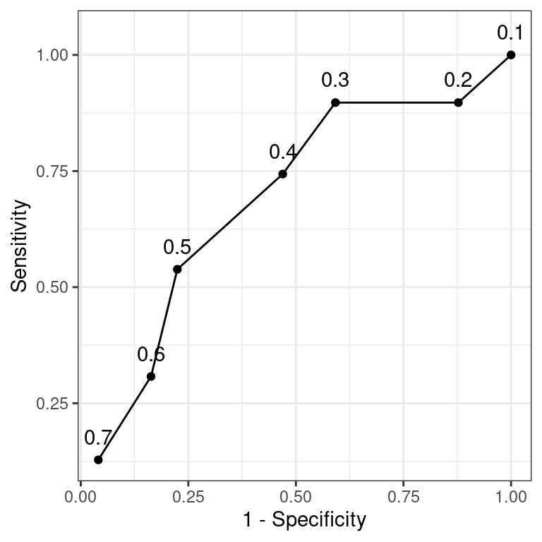

This plot is known as a [*receiver operating characteristic (ROC) curve*](https://en.wikipedia.org/wiki/Receiver_operating_characteristic), the name resulting from the fact that it was created during WWII by electrical and radar engineers for detecting enemy combatants in the battle field.

Rather than computing ROC values ourselves, we can use the `plotROC` package in R which adds `geom_roc()` to the suite of ggplot functions. Note that this functions uses the aesthetics `d` and `m` for “disease” and “marker”, respectively

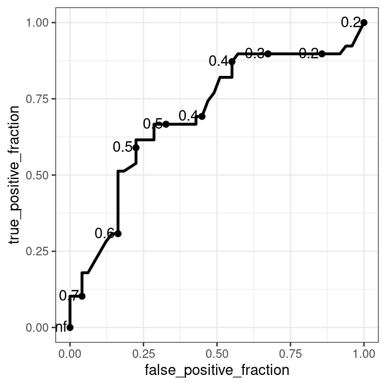

```r
library(plotROC)

## Add fitted values (probabilities) to our data
dat$fitval <- fitted(fit)
ggplot(dat) + geom_roc(aes(d = death, m = fitval))
```

A nice aspect of the ggplot version of ROC is that it allows you to color by groups, giving us the ability to compare ROC curves from both male and female populations

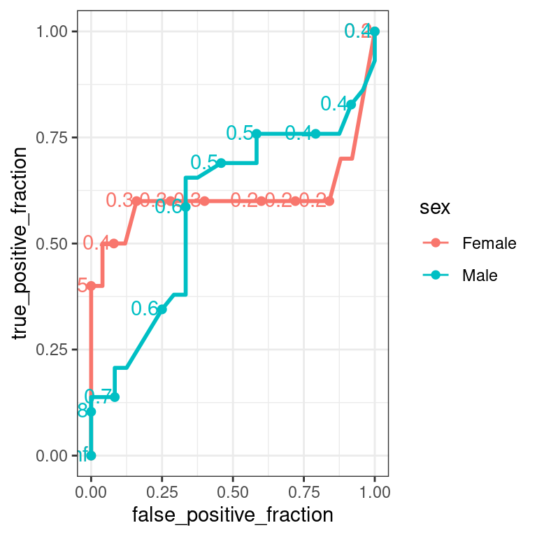

```r
ggplot(dat) + geom_roc(aes(d = death, m = fitval, color = sex))
```

**Question 6:** Based on the ROC plot by sex above, is it obvious that our model performs better at predicting either male or female? How would you decide which sex had the better predictions?

### AUC

As we just saw in question 6, it can be difficult to simply look at two ROC curves and say that one is better than the other. We will start this section with a few observations.

First, we might say that the *ideal* case is one in which our true positive rate is 100% while our false positive rate is 0%. We will indicate place on the graph with a blue dot.

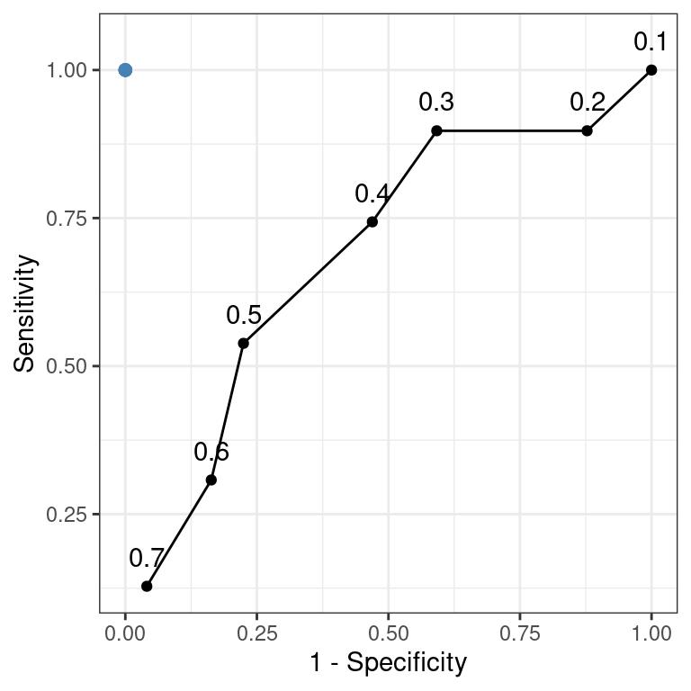

The worst possible situation would be the converse: we have a 100% false positive rate with a 0% true positive rate. We will mark this spot in red. Together, these represent the two extremes.

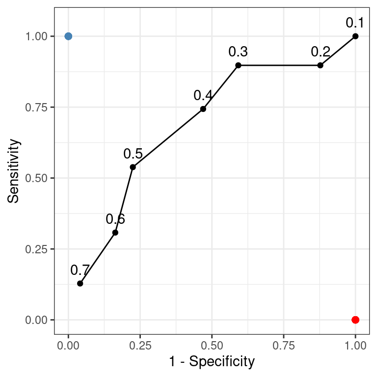

The most average case comes from simple guessing, a situation in which our probability of correctly identifying a positive is the same as our probability of falsely identifying a positive. We call this situation *no better than chance*, and we will represent it with an orange dot.

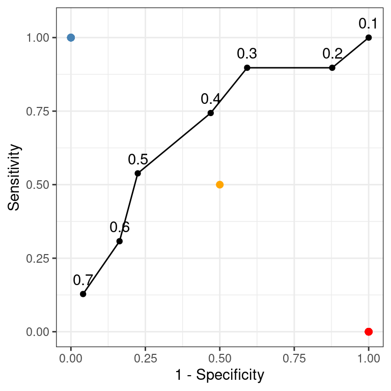

In fact, there are many such instances in which the true positive rate is equal to the false positive rate, enough that our “no better than chance” can be represented by a line

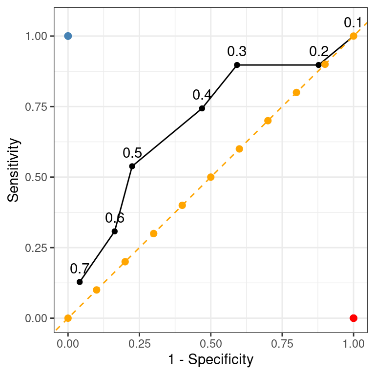

This adds quite a bit of context to our interpretation of the ROC curve. *Now* we see that a threshold of 0.5 performs much better than chance, while a threshold of 0.2 does as well as random guessing.

The quality of a model, however, is not determined by any particular point on the ROC curve, but rather on the quality of the ROC curve as a whole. To this end, we need a metric that summarizes it. Such a metric is implied by the orange line above.

Note that the orange line bisects a square with sides of length 1. As such, the *area under the curve (AUC)* is equal to 0.5. Alternatively, consider again our best case scenario, where we achieve a true positive rate of 100% and a false positive rate of 0%. This would have an AUC of 1.0.

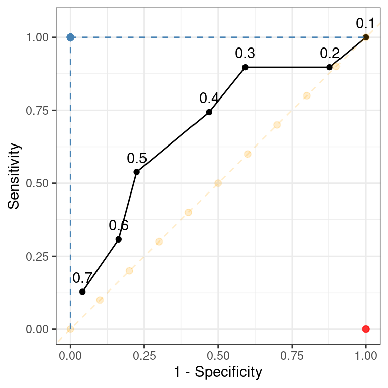

Our curve happens to be somewhere in between “best scenario” and “no better than chance”. While there are several packages that will compute the AUC of the ROC for us, we can use the `calc_auc()` function provided by the `plotROC` package. To use it, save the ggplot with ROC to a variable and then compute AUC.

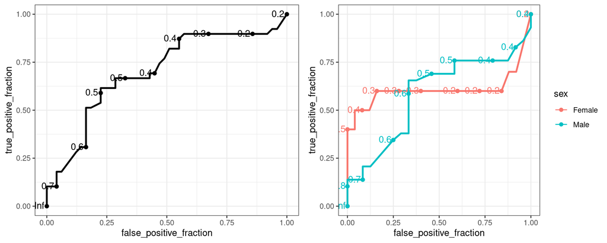

```r
library(plotROC)

roc <- ggplot(dat) + geom_roc(aes(d = death, m = fitval))
roc_sex <- ggplot(dat, aes(d = death, m = fitval, color = sex)) + geom_roc()

gridExtra::grid.arrange(roc, roc_sex, nrow = 1)
```

```r
# AUC for overall ROC curve
calc_auc(roc)
```

```
##   PANEL group     AUC
## 1     1    -1 0.69911
```

```r
# AUC for each sex's ROC curve
calc_auc(roc_sex)
```

```
##   PANEL group    sex    AUC
## 1     1     1 Female 0.6080
## 2     1     2   Male 0.5819
```

In general, the AUC of an ROC curve can be used as a reliable metric for assessing the quality of prediction in a logistic regression model.

**Question 7:** Return to question 3 where we fit the two models predicting win probabilities, one with the variable `FG3A` and the other with both `FG3A` and `FG3`. Create ROC curves for each of these models and find the AUC.

```r
gsw <- read.csv("https://remiller1450.github.io/data/GSWarriors.csv")
gsw$win_binary <- ifelse(gsw$Win == "W", 1, 0)
```